# IMF Primary Commodity Prices

アセット･マネジメント･コンサルティング株式会社 http://am-consulting.co.jp

2017-05-17 14:16:56

- アセット･マネジメント･コンサルティング株式会社 http://am-consulting.co.jp
- SaECaNet http://saecanet.com/
- Olive http://olive.saecanet.com/
- twitter https://twitter.com/AMC2_Japan
- 本ページへのリンクを共有:[Tweet](https://twitter.com/share)
- タイトル : IMF Primary Commodity Prices:2017-04:All Commodity Price Index, 2005 = 100, includes both Fuel and Non-Fuel Price Indices . Type: Index:113.28
- データ出所 : International Monetary Fund
- Source http://www.imf.org/external/np/res/commod/index.aspx

#### 直近月の前年同月比(%) / Year over Year of Latest Data

| ID | Item | 2017-04 |
| --- | --- | --- |
| 1 | All Commodity Price Index, 2005 = 100, includes both Fuel and Non-Fuel Price Indices . Type: Index | [17.5] |
| 2 | Non-Fuel Price Index, 2005 = 100, includes Food and Beverages and Industrial Inputs Price Indices . Type: Index | [5.9] |
| 3 | Food and Beverage Price Index, 2005 = 100, includes Food and Beverage Price Indices . Type: Index | [0.3] |
| 4 | Food Price Index, 2005 = 100, includes Cereal, Vegetable Oils, Meat, Seafood, Sugar, Bananas, and Oranges Price Indices . Type: Index | [1.1] |
| 5 | Beverage Price Index, 2005 = 100, includes Coffee, Tea, and Cocoa . Type: Index | [-7] |
| 6 | Industrial Inputs Price Index, 2005 = 100, includes Agricultural Raw Materials and Metals Price Indices . Type: Index | [12.9] |
| 7 | Agricultural Raw Materials Index, 2005 = 100, includes Timber, Cotton, Wool, Rubber, and Hides Price Indices . Type: Index | [5.4] |
| 8 | Metals Price Index, 2005 = 100, includes Copper, Aluminum, Iron Ore, Tin, Nickel, Zinc, Lead, and Uranium Price Indices . Type: Index | [18.1] |
| 9 | Fuel (Energy) Index, 2005 = 100, includes Crude oil (petroleum), Natural Gas, and Coal Price Indices . Type: Index | [29.1] |
| 10 | Crude Oil (petroleum), Price index, 2005 = 100, simple average of three spot prices; Dated Brent, West Texas Intermediate, and the Dubai Fateh . Type: Index | [28.4] |

[output cut: 53 more lines]

##### All Commodity Price Index, 2005 = 100, includes both Fuel and Non-Fuel Price Indices . Type: Index

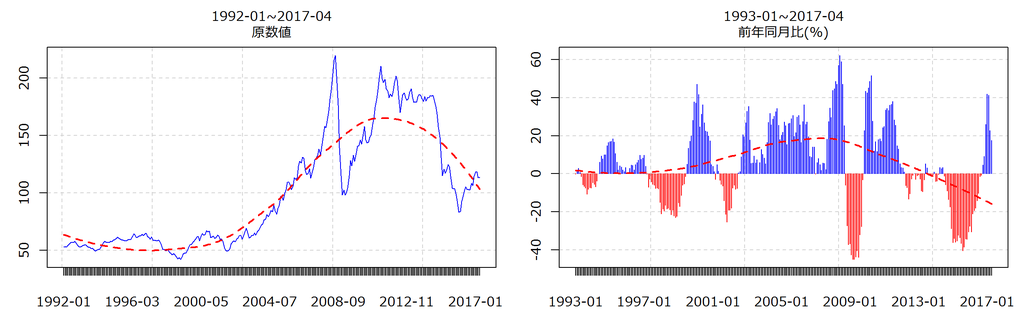

##### Non-Fuel Price Index, 2005 = 100, includes Food and Beverages and Industrial Inputs Price Indices . Type: Index

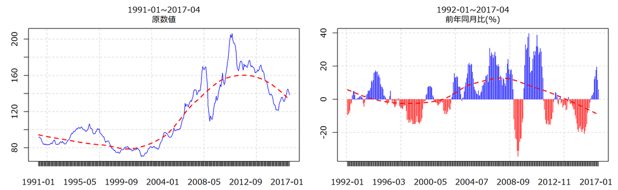

##### Food and Beverage Price Index, 2005 = 100, includes Food and Beverage Price Indices . Type: Index

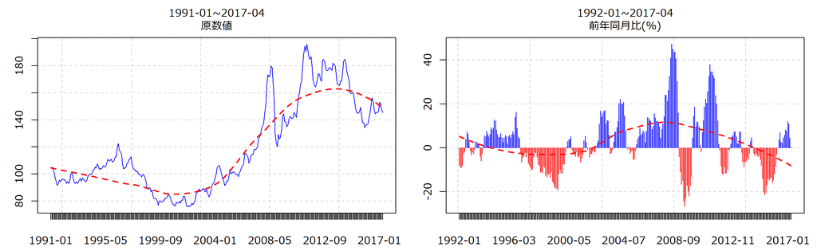

##### Food Price Index, 2005 = 100, includes Cereal, Vegetable Oils, Meat, Seafood, Sugar, Bananas, and Oranges Price Indices . Type: Index

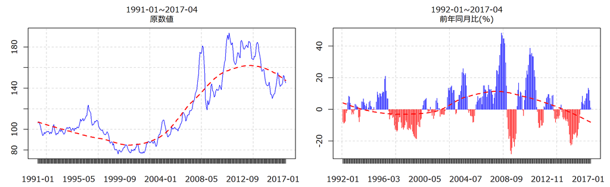

##### Beverage Price Index, 2005 = 100, includes Coffee, Tea, and Cocoa . Type: Index

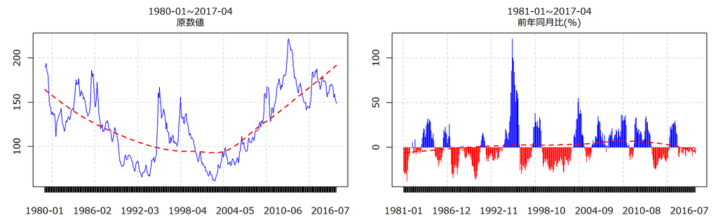

##### Industrial Inputs Price Index, 2005 = 100, includes Agricultural Raw Materials and Metals Price Indices . Type: Index

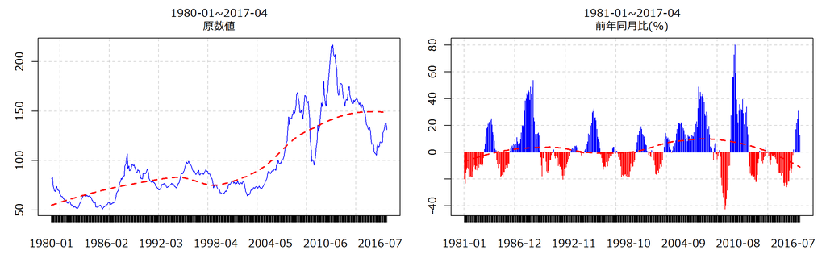

##### Agricultural Raw Materials Index, 2005 = 100, includes Timber, Cotton, Wool, Rubber, and Hides Price Indices . Type: Index

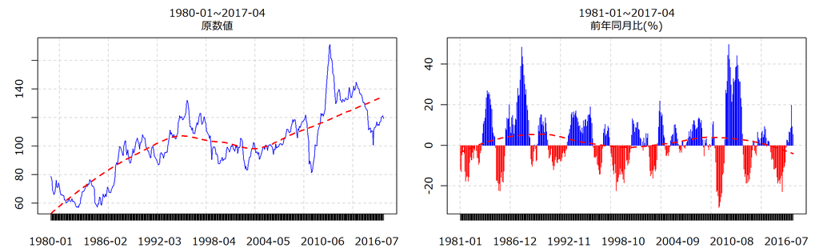

##### Metals Price Index, 2005 = 100, includes Copper, Aluminum, Iron Ore, Tin, Nickel, Zinc, Lead, and Uranium Price Indices . Type: Index

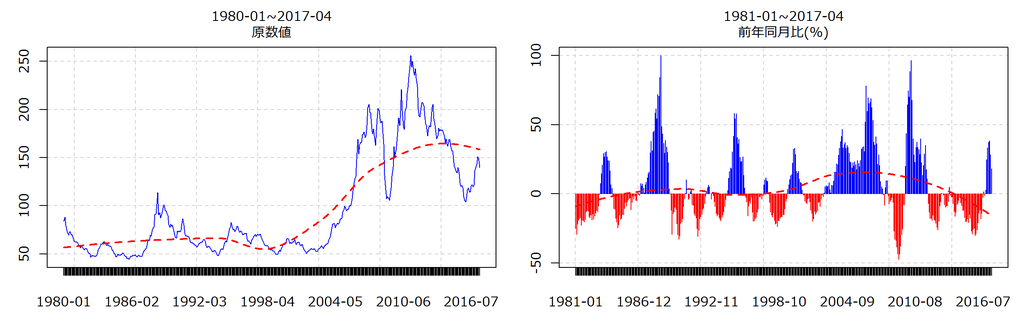

##### Fuel (Energy) Index, 2005 = 100, includes Crude oil (petroleum), Natural Gas, and Coal Price Indices . Type: Index

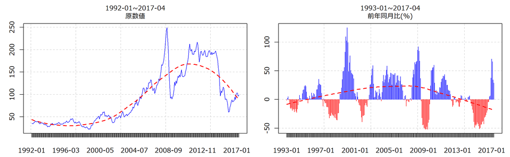

##### Crude Oil (petroleum), Price index, 2005 = 100, simple average of three spot prices; Dated Brent, West Texas Intermediate, and the Dubai Fateh . Type: Index

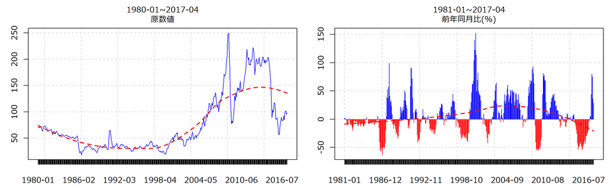

##### Aluminum, 99.5% minimum purity, LME spot price, CIF UK ports, US$ per metric ton . Type: USD

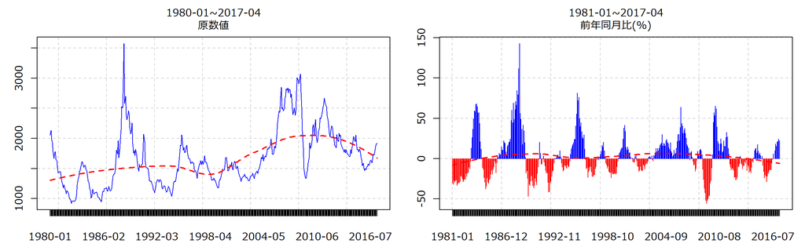

##### Bananas, Central American and Ecuador, FOB U.S. Ports, US$ per metric ton . Type: USD

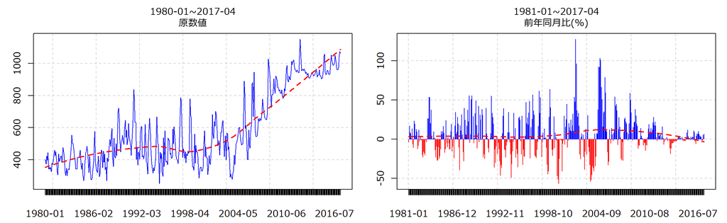

##### Barley, Canadian no.1 Western Barley, spot price, US$ per metric ton . Type: USD

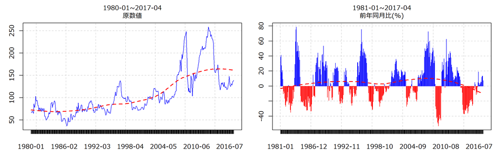

##### Beef, Australian and New Zealand 85% lean fores, CIF U.S. import price, US cents per pound . Type: USD

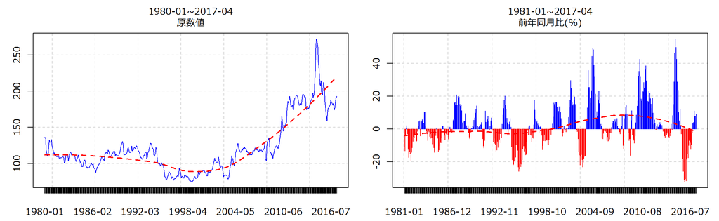

##### Coal, Australian thermal coal, 12,000- btu/pound, less than 1% sulfur, 14% ash, FOB Newcastle/Port Kembla, US$ per metric ton . Type: USD

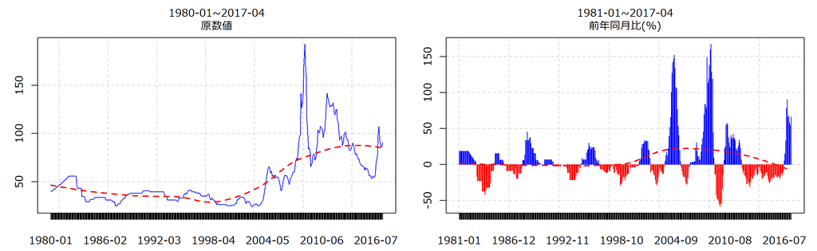

##### Cocoa beans, International Cocoa Organization cash price, CIF US and European ports, US$ per metric ton . Type: USD

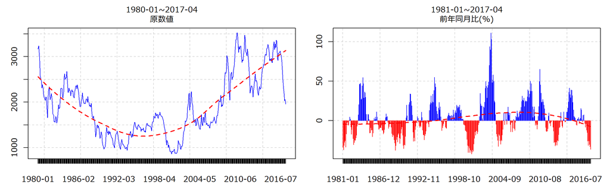

##### Coffee, Other Mild Arabicas, International Coffee Organization New York cash price, ex-dock New York, US cents per pound . Type: USD

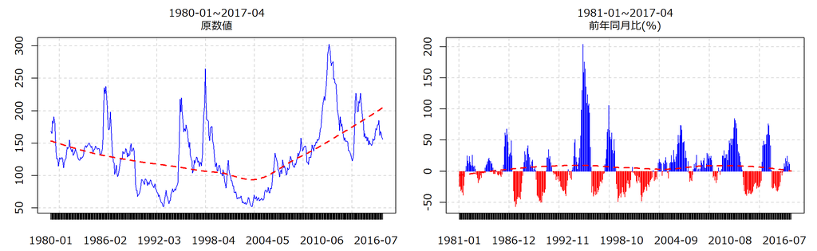

##### Coffee, Robusta, International Coffee Organization New York cash price, ex-dock New York, US cents per pound . Type: USD

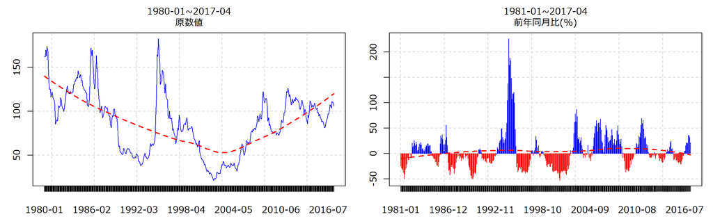

##### Rapeseed oil, crude, fob Rotterdam, US$ per metric ton . Type: USD

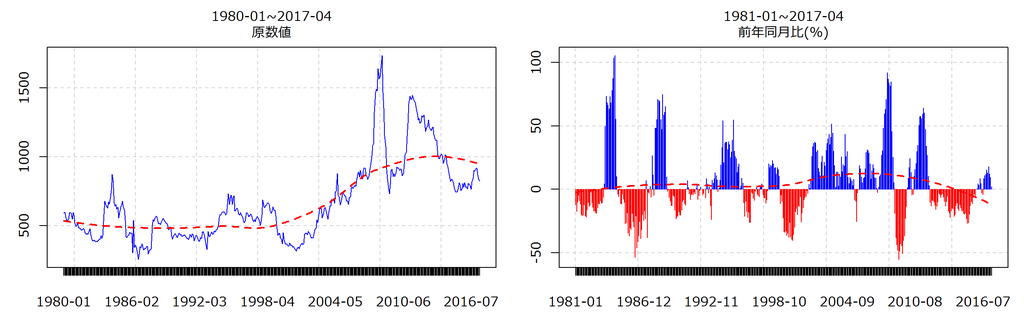

##### Copper, grade A cathode, LME spot price, CIF European ports, US$ per metric ton . Type: USD

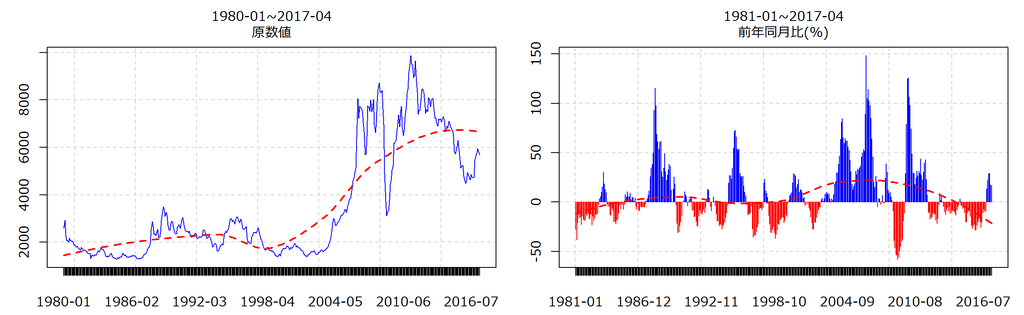

##### Cotton, Cotton Outlook ‘A Index’, Middling 1-3/32 inch staple, CIF Liverpool, US cents per pound . Type: USD

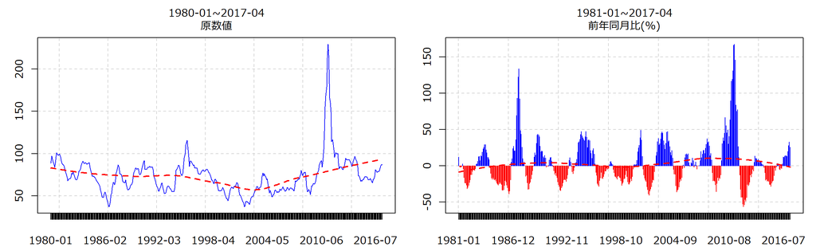

##### Fishmeal, Peru Fish meal/pellets 65% protein, CIF, US$ per metric ton . Type: USD

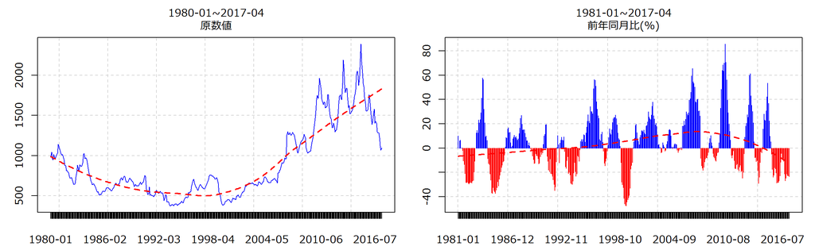

##### Groundnuts (peanuts), 40/50 (40 to 50 count per ounce), cif Argentina, US$ per metric ton . Type: USD

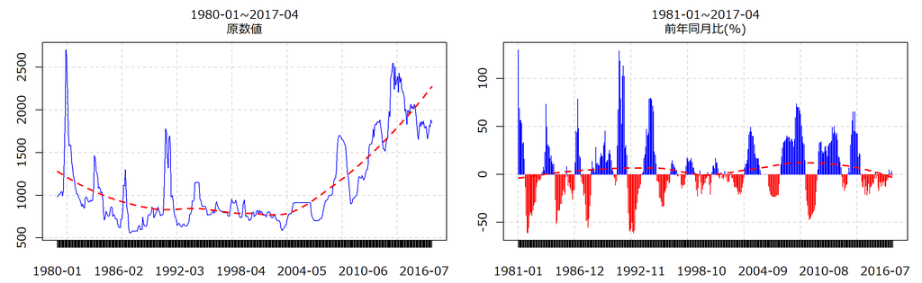

##### Hides, Heavy native steers, over 53 pounds, wholesale dealer’s price, US, Chicago, fob Shipping Point, US cents per pound . Type: USD

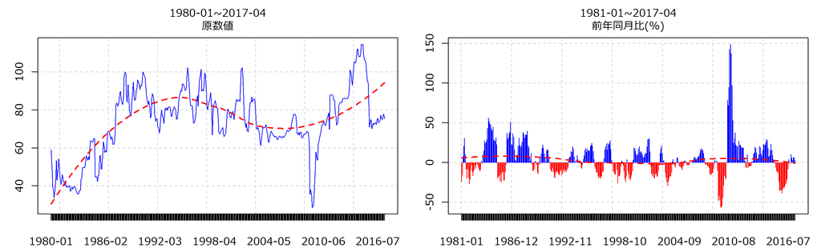

##### China import Iron Ore Fines 62% FE spot (CFR Tianjin port), US dollars per metric ton . Type: USD

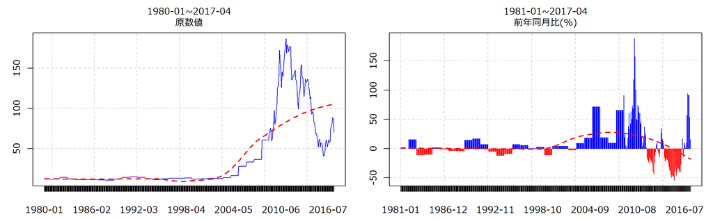

##### Lamb, frozen carcass Smithfield London, US cents per pound . Type: USD

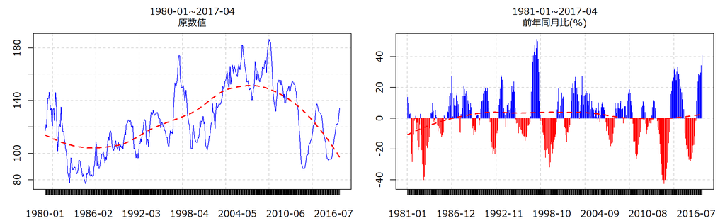

##### Lead, 99.97% pure, LME spot price, CIF European Ports, US$ per metric ton . Type: USD

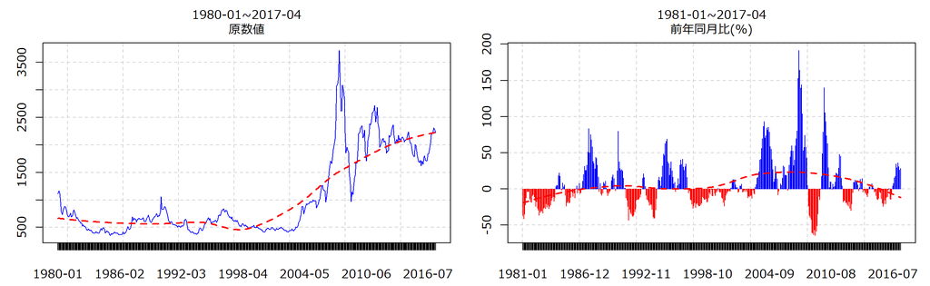

##### Soft Logs, Average Export price from the U.S. for Douglas Fir, US$ per cubic meter . Type: USD

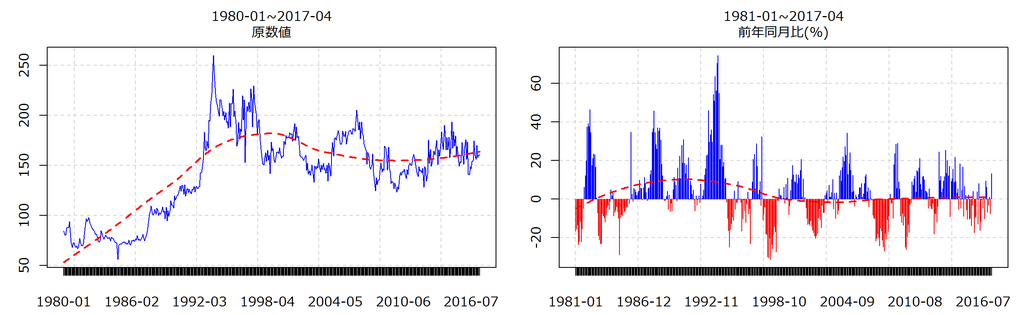